# Sales Dashboard

Sudharsan B

2024-04-15

# Dashboard using R Programming

## Data

```r
library(readr)
library(scales)
data = read.csv("data.csv")
head(data,10)
```

```
##       Retailer Retailer.ID Invoice.Date    Region    State     City
## 1  Foot Locker     1185732     1/1/2020 Northeast New York New York
## 2  Foot Locker     1185732     1/2/2020 Northeast New York New York
## 3  Foot Locker     1185732     1/3/2020 Northeast New York New York
## 4  Foot Locker     1185732     1/4/2020 Northeast New York New York
## 5  Foot Locker     1185732     1/5/2020 Northeast New York New York
## 6  Foot Locker     1185732     1/6/2020 Northeast New York New York
## 7  Foot Locker     1185732     1/7/2020 Northeast New York New York
## 8  Foot Locker     1185732     1/8/2020 Northeast New York New York
## 9  Foot Locker     1185732    1/21/2020 Northeast New York New York
## 10 Foot Locker     1185732    1/22/2020 Northeast New York New York
##                      Product Price.per.Unit Units.Sold Total.Sales
## 1      Men's Street Footwear             50      1,200      600000
## 2    Men's Athletic Footwear             50      1,000      500000
## 3    Women's Street Footwear             40      1,000      400000
```

[output cut: 18 more lines]

### Objective 1

- Aims to monitor the total sales collected on a monthly basis for the years 2020 and 2021.
- This involves tracking the sum of sales values recorded each month throughout these two years.
- By collecting and visualizing this data, stakeholders can gain insights into the sales performance over time, identify patterns or trends in sales, and make informed decisions to improve sales strategies or allocate resources effectively.
- The objective is to provide a clear understanding of how sales have varied from month to month across the specified time period.

#### By using Graph

```r
df <- data.frame(Date = as.Date(data$Invoice.Date, format = "%m/%d/%Y"), Value = data$Total.Sales)
# Convert Date column to year-month format

library(zoo)
df$Date <- as.yearmon(df$Date)

df$Value <- as.numeric(df$Value)

# Filter and summarise
library(dplyr)
```

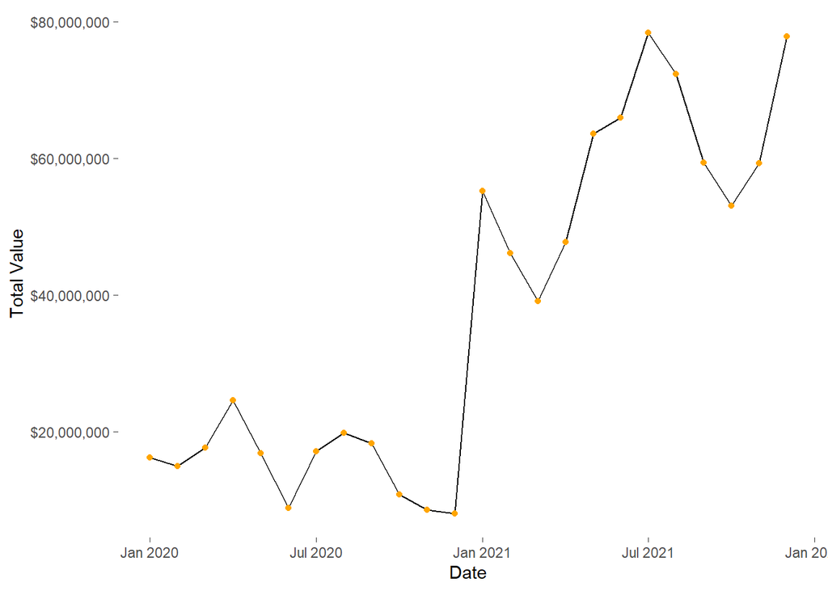

```r
library(scales)
library(ggplot2)
d <- df %>%
  group_by(Date) %>%
  summarise(total_value = sum(Value, na.rm = TRUE))


# Assuming 'd' contains the summarized data
ggplot(d, aes(x = Date, y = total_value, group = 1)) +
  geom_line(color = "black") +
  geom_point(color = "orange") + # Add points for better visualization
  labs(x = "Date", y = "Total Value") +
  scale_y_continuous(labels = scales::dollar_format(scale = 1e-0)) +  # Adjust scale as needed
  theme_dark() + # Set the theme to dark
  theme(panel.background = element_rect(fill = "white"),
        panel.grid.major = element_blank(),  # Remove major grid lines
        panel.grid.minor = element_blank(),  # Remove minor grid lines
        panel.border = element_blank())
```

### Objective 2

- This is to visually analyze the earnings of different retailers in comparison to the total earnings using a pie chart.
- This involves collecting earnings data for each retailer, aggregating the data to calculate total earnings per retailer, and then representing these proportions in a pie chart to gain insights into each retailer’s contribution to the overall earnings

```r
df1 = data.frame(Date = as.Date(data$Invoice.Date, format = "%m/%d/%Y"),Retailers = data$Retailer,Total_Sales= data$Total.Sales)
head(df1,10)
```

```
##          Date   Retailers Total_Sales
## 1  2020-01-01 Foot Locker      600000
## 2  2020-01-02 Foot Locker      500000
## 3  2020-01-03 Foot Locker      400000
## 4  2020-01-04 Foot Locker      382500
## 5  2020-01-05 Foot Locker      540000
## 6  2020-01-06 Foot Locker      500000
## 7  2020-01-07 Foot Locker      625000
## 8  2020-01-08 Foot Locker      450000
## 9  2020-01-21 Foot Locker      380000
## 10 2020-01-22 Foot Locker      371250
```

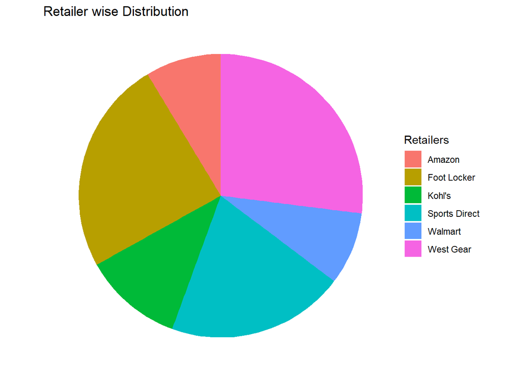

```r
library(dplyr)


library(scales)
library(ggplot2)

df_agg <- df1 %>%
  group_by(Retailers) %>%
  summarise(Total_Earnings = sum(Total_Sales)) %>%
  arrange(desc(Total_Earnings))
# Analyze the Retailers Earnings with Total Earnings using Pie Chart

ggplot(df_agg, aes(x = "", y = Total_Earnings, fill = Retailers)) +
  geom_bar(stat = "identity", width = 1) +
  coord_polar("y", start = 0) +
  theme_void() +
  theme(legend.position = "right") +
  labs(title = "Retailer wise Distribution",
       fill = "Retailers",
       y = "Total Earnings")
```

### Objective 3

- The objective is to analyze the earnings of different regions and compare them to the total earnings using a pie chart.
- This entails gathering earnings data categorized by region, aggregating the data to compute total earnings for each region, and subsequently visualizing these proportions in a pie chart.
- The aim is to understand the distribution of earnings across various regions and to identify which regions contribute the most to the overall earnings.

```r
df2 = data.frame(Date = as.Date(data$Invoice.Date, format = "%m/%d/%Y"),Region = data$Region,Total_Sales= data$Total.Sales)
head(df2,10)
```

```
##          Date    Region Total_Sales
## 1  2020-01-01 Northeast      600000
## 2  2020-01-02 Northeast      500000
## 3  2020-01-03 Northeast      400000
## 4  2020-01-04 Northeast      382500
## 5  2020-01-05 Northeast      540000
## 6  2020-01-06 Northeast      500000
## 7  2020-01-07 Northeast      625000
## 8  2020-01-08 Northeast      450000
## 9  2020-01-21 Northeast      380000
## 10 2020-01-22 Northeast      371250
```

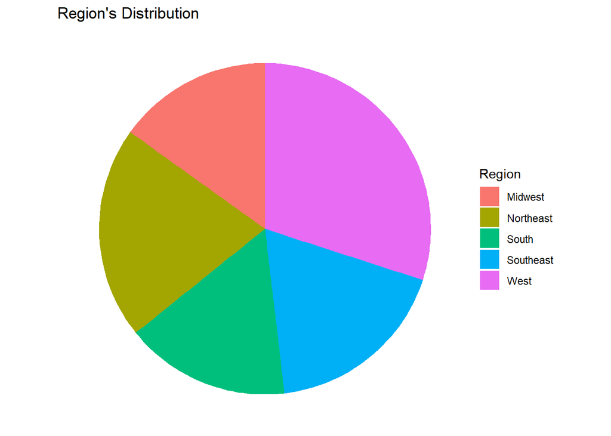

```r
library(dplyr)


library(scales)
library(ggplot2)

df_agg2 <- df2 %>%
  group_by(Region) %>%
  summarise(Total_Earnings = sum(Total_Sales)) %>%
  arrange(desc(Total_Earnings))
# Analyze the Retailers Earnings with Total Earnings using Pie Chart

ggplot(df_agg2, aes(x = "", y = Total_Earnings, fill = Region)) +
  geom_bar(stat = "identity", width = 1) +
  coord_polar("y", start = 0) +
  theme_void() +
  theme(legend.position = "right") +
  labs(title = "Region's Distribution",
       fill = "Region",
       y = "Total Earnings")
```

### Objective 4

- This objective is to analyze the earnings generated through different sales methods and compare them to the total earnings using a pie chart.
- This involves collecting earnings data categorized by sales method, aggregating the data to calculate total earnings for each method, and then visualizing these proportions in a pie chart.
- The goal is to gain insights into the contribution of each sales method to the overall earnings and to identify which methods are most effective in generating revenue.

```r
df3 = data.frame(Date = as.Date(data$Invoice.Date, format = "%m/%d/%Y"),Sales_method = data$Sales.Method,Total_Sales= data$Total.Sales)
head(df3,10)
```

```
##          Date Sales_method Total_Sales
## 1  2020-01-01     In-store      600000
## 2  2020-01-02     In-store      500000
## 3  2020-01-03     In-store      400000
## 4  2020-01-04     In-store      382500
## 5  2020-01-05     In-store      540000
## 6  2020-01-06     In-store      500000
## 7  2020-01-07     In-store      625000
## 8  2020-01-08       Outlet      450000
## 9  2020-01-21       Outlet      380000
## 10 2020-01-22       Outlet      371250
```

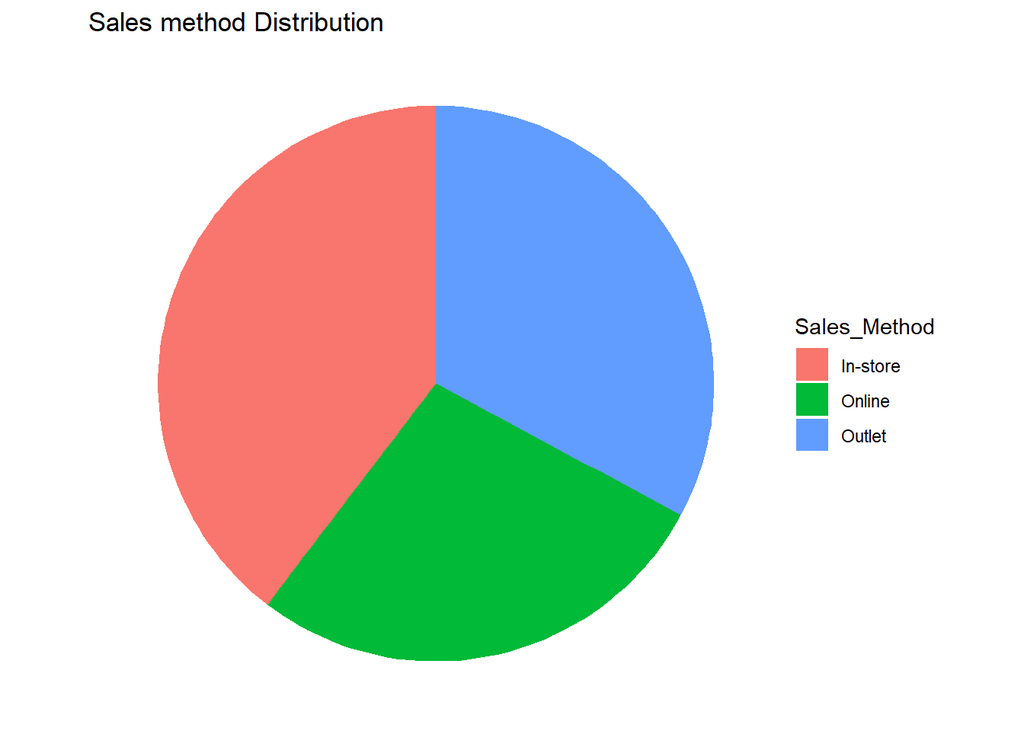

```r
library(dplyr)


library(scales)
library(ggplot2)

df_agg1 <- df3 %>%
  group_by(Sales_method) %>%
  summarise(Total_Earnings = sum(Total_Sales)) %>%
  arrange(desc(Total_Earnings))
# Analyze the Retailers Earnings with Total Earnings using Pie Chart

ggplot(df_agg1, aes(x = "", y = Total_Earnings, fill = Sales_method)) +
  geom_bar(stat = "identity", width = 1) +
  coord_polar("y", start = 0) +
  theme_void() +
  theme(legend.position = "right") +
  labs(title = "Sales method Distribution",
       fill = "Sales_Method",
       y = "Total Earnings")
```